# 项目：调查TMDb电影数据

## 目录

- 简介
- 数据整理
- 探索性数据分析
- 结论

## 简介

> 分析的数据集来源为“电影数据库”（TMDb，The Movie Database），包含一万余条电影信息，主要信息包括受欢迎程度、收入及预算、电影原标题、演员及导演、发行日期、电影描述关键词等。探索的问题为：每年最受欢迎的电影的体裁是哪些？查询的关键信息为年份、受欢迎程度及体裁，查看每年最受欢迎电影的体裁，并分别统计每种体裁的数量；票房高的电影有哪些特点？关键信息为票房、受欢迎程度、评分数量、预算等。

## 数据整理

### 常规属性

> 初始数据包含 id、网络电影数据库ID、受欢迎程度、预算、收入、原标题、演员、主页、导演、品牌理念、关键词、概述、时长、体裁、制片公司、发行日期、评分数量、平均评分、发行年份、预算（考虑通胀）、收入（考虑通胀），共 10866 行，21 列

### 导入数据并查看基本信息

```python
import pandas as pd
import numpy as np
import matplotlib.pyplot as plt
%matplotlib inline
```

```python
df = pd.read_csv('tmdb-movies.csv')
df.head(1)
```

|  | id | imdb_id | popularity | budget | revenue | original_title | cast | homepage | director | tagline | ... | overview | runtime | genres | production_companies | release_date | vote_count | vote_average | release_year | budget_adj | revenue_adj |
| --- | --- | --- | --- | --- | --- | --- | --- | --- | --- | --- | --- | --- | --- | --- | --- | --- | --- | --- | --- | --- | --- |
| 0 | 135397 | tt0369610 | 32.985763 | 150000000 | 1513528810 | Jurassic World | Chris Pratt\|Bryce Dallas Howard\|Irrfan Khan\|Vi... | http://www.jurassicworld.com/ | Colin Trevorrow | The park is open. | ... | Twenty-two years after the events of Jurassic ... | 124 | Action\|Adventure\|Science Fiction\|Thriller | Universal Studios\|Amblin Entertainment\|Legenda... | 6/9/15 | 5562 | 6.5 | 2015 | 1.379999e+08 | 1.392446e+09 |

1 rows × 21 columns

```python
df.info()
```

```
<class 'pandas.core.frame.DataFrame'>
RangeIndex: 10866 entries, 0 to 10865
Data columns (total 21 columns):
id                      10866 non-null int64
imdb_id                 10856 non-null object
popularity              10866 non-null float64
budget                  10866 non-null int64
revenue                 10866 non-null int64
original_title          10866 non-null object
cast                    10790 non-null object
homepage                2936 non-null object
director                10822 non-null object
tagline                 8042 non-null object
keywords                9373 non-null object
overview                10862 non-null object
runtime                 10866 non-null int64
genres                  10843 non-null object
production_companies    9836 non-null object
release_date            10866 non-null object
vote_count              10866 non-null int64
vote_average            10866 non-null float64
release_year            10866 non-null int64
budget_adj              10866 non-null float64
revenue_adj             10866 non-null float64
dtypes: float64(4), int64(6), object(11)
memory usage: 1.7+ MB
```

### 数据清理：删掉无关列、电影体裁含有 NaN 值的行、重复行

电影主页（homepage）、品牌理念（tagline）制片公司（production_companies）缺失值比较多，对于分析问题也几乎无帮助，所以删掉这三列。imdb_id 与分析无特别关系，删掉该列，有体裁（genres）数据，则关键词（keywords）概述（overview）列对分析也无很大影响，删掉。对于票房及预算来讲，计算通货膨胀数据对票房大小的对比无关，删掉。

```python
df.drop(['homepage', 'tagline', 'production_companies', 'imdb_id','keywords',
         'overview', 'budget_adj', 'revenue_adj'], axis=1, inplace=True)  # 删掉无关列
df['bool'] = df['genres'].isnull()
df.drop(df[df['bool'] == True].index, inplace=True)  # 删掉电影体裁含有 NaN 值的行
df.drop(columns='bool', inplace=True)
```

删掉电影体裁含有 NaN 值时，通过添加新的 bool 列，判断此行是否有空值，True 为含有空值，所以删掉该行 bool 列值为 True 的行。然后删掉 bool 列，其他行的空值如演员、导演对问题分析无特别关系，可以不删掉带有空值的行，以防删掉一些电影数据。

```python
df.drop_duplicates(inplace=True)  # 删除重复行
df.info()
```

```
<class 'pandas.core.frame.DataFrame'>
Int64Index: 10842 entries, 0 to 10865
Data columns (total 13 columns):
id                10842 non-null int64
popularity        10842 non-null float64
budget            10842 non-null int64
revenue           10842 non-null int64
original_title    10842 non-null object
cast              10767 non-null object
director          10800 non-null object
runtime           10842 non-null int64
genres            10842 non-null object
release_date      10842 non-null object
vote_count        10842 non-null int64
vote_average      10842 non-null float64
release_year      10842 non-null int64
dtypes: float64(2), int64(6), object(5)
memory usage: 1.2+ MB
```

在清理数据过程中测试过是否删掉了某年最受欢迎的电影，测试结果显示没有删掉，为了保证报告的简洁性，测试过后即删掉测试代码，在此不做展示。

```python
df.head(1)
```

|  | id | popularity | budget | revenue | original_title | cast | director | runtime | genres | release_date | vote_count | vote_average | release_year |
| --- | --- | --- | --- | --- | --- | --- | --- | --- | --- | --- | --- | --- | --- |
| 0 | 135397 | 32.985763 | 150000000 | 1513528810 | Jurassic World | Chris Pratt\|Bryce Dallas Howard\|Irrfan Khan\|Vi... | Colin Trevorrow | 124 | Action\|Adventure\|Science Fiction\|Thriller | 6/9/15 | 5562 | 6.5 | 2015 |

## 探索性数据分析

### 每年最受欢迎的电影的体裁是什么？

```python
df_pop = df.groupby('release_year')['popularity'].max()  # 每年最受欢迎的电影
```

按照年份分组，求每年最受欢迎的电影的受欢迎程度值。清理数据时测试过有没有清理掉某年最受欢迎的电影，测试结果显示并没有。

```python
df_most = df[df['popularity'].isin(df_pop)]['genres']  # 每年最受欢迎电影体裁
```

求每年最受欢迎电影的体裁是什么，也就是受欢迎程度列的值等于上一行求出的每年受欢迎程度的最大值，其中测试过受欢迎程度值的重复数量，但并没有最大值重复，所以不用担心数据冗余，为保证报告简洁，测试代码删掉。

```python
df_split = df_most.str.split('|', expand=True)  # 电影体裁分割生成新列
df_split.tail(2)
```

|  | 0 | 1 | 2 | 3 | 4 |
| --- | --- | --- | --- | --- | --- |
| 10755 | Music | None | None | None | None |
| 10820 | Animation | Family | Comedy | None | None |

把电影体裁按照|字符分割，也就是分割成所有电影的体裁，用来分别统计单一体裁的数量。

```python
df_num = df_split[0]  # 统计每种体裁的数量
for i in [1,2,3,4]:
    df_num = df_num.append(df_split[i])
df_num = df_num.value_counts()
```

把每一列都加到第一列的后面，五列合成一列，然后统计出来的唯一值数量即是每种电影体裁的数量。

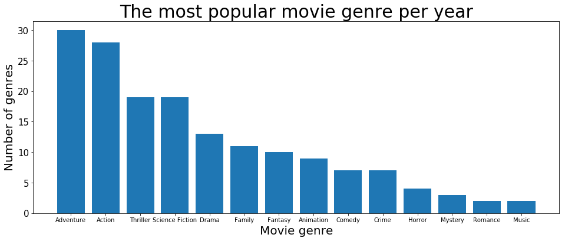

```python
plt.subplots(figsize=(16, 6))  # 直方图可视化
plt.bar(df_num.index, df_num)
plt.xticks(fontsize=10)
plt.yticks(fontsize=15)
plt.title('The most popular movie genre per year', fontsize=30)
plt.xlabel('Movie genre', fontsize=20)
plt.ylabel('Number of genres', fontsize=20);
```

因为要统计体裁的数量，所以直方图比较直观合适。体裁类别名称较长，为了不让 x 轴标签重合，所以图设置的较长，x 标签即每种电影体裁，y 轴数量即表示这些年来最受欢迎电影的体裁数量。每年最受欢迎的电影中包含冒险、动作体裁的电影较多，而浪漫、音乐体裁较少。

### 票房高的电影有哪些特点？

```python
# 删掉无关或者字符类型数据
df_rev = df.drop(['id', 'original_title', 'cast', 'director',
                   'genres', 'release_date'], axis=1)
df_rev.describe()
```

|  | popularity | budget | revenue | runtime | vote_count | vote_average | release_year |
| --- | --- | --- | --- | --- | --- | --- | --- |
| count | 10842.000000 | 1.084200e+04 | 1.084200e+04 | 10842.000000 | 10842.000000 | 10842.000000 | 10842.000000 |
| mean | 0.647461 | 1.465531e+07 | 3.991138e+07 | 102.138443 | 217.823649 | 5.974064 | 2001.314794 |
| std | 1.001032 | 3.093971e+07 | 1.171179e+08 | 31.294612 | 576.180993 | 0.934257 | 12.813617 |
| min | 0.000065 | 0.000000e+00 | 0.000000e+00 | 0.000000 | 10.000000 | 1.500000 | 1960.000000 |
| 25% | 0.208210 | 0.000000e+00 | 0.000000e+00 | 90.000000 | 17.000000 | 5.400000 | 1995.000000 |
| 50% | 0.384532 | 0.000000e+00 | 0.000000e+00 | 99.000000 | 38.000000 | 6.000000 | 2006.000000 |
| 75% | 0.715393 | 1.500000e+07 | 2.414118e+07 | 111.000000 | 146.000000 | 6.600000 | 2011.000000 |
| max | 32.985763 | 4.250000e+08 | 2.781506e+09 | 900.000000 | 9767.000000 | 9.200000 | 2015.000000 |

id、标题、作者、导演、体裁、发行日期的列值较难统计数据且与票房相关性可能并不大，所以删掉。用描述统计函数分析每类数据，其中预算及票房值 0 值非常多，到了第三分位数才有值，所以用票房第三分位数来区分票房较高的电影和较低的电影。

```python
q3_rev = df_rev.describe()['revenue'][-2]  # 因为第一二分位数为 0，所以用第三分位数为分界依据
```

```python
df_high = df_rev.query('revenue > {}'.format(q3_rev))  # 票房高的电影
df_low = df_rev.query('revenue <= {}'.format(q3_rev))  # 票房低的电影
df_high = df_high.drop('revenue', axis=1)  # 删掉票房列，不需要在结果图中展示票房
df_low = df_low.drop('revenue', axis=1)  # 删掉票房列，不需要在结果图中展示票房
```

```python
df_high.describe()
```

|  | popularity | budget | runtime | vote_count | vote_average | release_year |
| --- | --- | --- | --- | --- | --- | --- |
| count | 2711.000000 | 2.711000e+03 | 2711.000000 | 2711.000000 | 2711.000000 | 2711.000000 |
| mean | 1.454374 | 4.542885e+07 | 111.729989 | 698.040207 | 6.259535 | 2001.112873 |
| std | 1.661620 | 4.631808e+07 | 22.881649 | 992.637617 | 0.748093 | 11.115354 |
| min | 0.010335 | 0.000000e+00 | 44.000000 | 10.000000 | 3.400000 | 1960.000000 |
| 25% | 0.617419 | 1.400000e+07 | 97.000000 | 144.000000 | 5.800000 | 1995.000000 |
| 50% | 1.029084 | 3.000000e+07 | 108.000000 | 331.000000 | 6.300000 | 2004.000000 |
| 75% | 1.691111 | 6.000000e+07 | 122.000000 | 805.000000 | 6.800000 | 2010.000000 |
| max | 32.985763 | 3.800000e+08 | 705.000000 | 9767.000000 | 8.400000 | 2015.000000 |

```python
df_low.describe()
```

|  | popularity | budget | runtime | vote_count | vote_average | release_year |
| --- | --- | --- | --- | --- | --- | --- |
| count | 8131.000000 | 8.131000e+03 | 8131.000000 | 8131.000000 | 8131.000000 | 8131.000000 |
| mean | 0.378423 | 4.394939e+06 | 98.940475 | 57.712090 | 5.878883 | 2001.382118 |
| std | 0.355495 | 1.184382e+07 | 33.022649 | 108.199786 | 0.970106 | 13.331795 |
| min | 0.000065 | 0.000000e+00 | 0.000000 | 10.000000 | 1.500000 | 1960.000000 |
| 25% | 0.169561 | 0.000000e+00 | 89.000000 | 14.000000 | 5.300000 | 1994.000000 |
| 50% | 0.296790 | 0.000000e+00 | 96.000000 | 25.000000 | 5.900000 | 2006.000000 |
| 75% | 0.477974 | 2.500000e+06 | 107.000000 | 55.000000 | 6.600000 | 2012.000000 |
| max | 8.411577 | 4.250000e+08 | 900.000000 | 2372.000000 | 9.200000 | 2015.000000 |

分别取出票房较高和较低的电影数据，然后删掉票房列数据，因为票房数据已经区分开，不需要再看图表。

```python
high_proportions = df_high.mean()/(df_high.mean()+df_low.mean())  # 票房高的电影数据占总数据的比例
low_proportions = df_low.mean()/(df_high.mean()+df_low.mean())  # 票房低的电影数据占总数据的比例
```

分别求出票房较高和较低的电影数据中的每个电影元素占总数据的百分比，通过比例来比较差异。

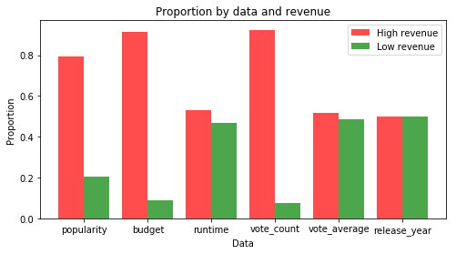

```python
plt.subplots(figsize=(8, 4))  # 直方图可视化
ind = np.arange(len(high_proportions))  # 组的 x 坐标位置
width = 0.4       # 条柱的宽度
high_bars = plt.bar(ind, high_proportions, width, color='r', alpha=.7, label='High revenue')
low_bars = plt.bar(ind + width, low_proportions, width, color='g', alpha=.7, label='Low revenue')
plt.ylabel('Proportion')
plt.xlabel('Data')
plt.title('Proportion by data and revenue')
locations = ind + width / 2  # x 坐标刻度位置
plt.xticks(locations, high_proportions.index);  # x 坐标刻度标签
plt.legend(loc='upper right');  # label 位置
```

分别画出高票房电影和低票房电影的数据，对比他们的每个元素的数据。图表数据显示，票房较高电影的受欢迎程度、电影预算、给电影评分的人数都较高，而电影时长、电影平均评分、发行年份则无特别差异。

上面通过比率来对比高低票房差异，下面通过量级来对比高低票房的差异，也就是用箱线图。因为量级的不同，所以分开展示。

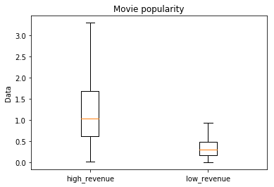

```python
plt.boxplot(x=(df_high['popularity'],df_low['popularity']),
            showfliers=False, meanline=True,
           labels=['high_revenue', 'low_revenue'])
plt.title('Movie popularity')
plt.ylabel('Data');
```

因为数据当中离群值较多，所以不显示离群值，上图显示，票房较低的大部分电影，受欢迎程度的值都在票房较高电影的中位数以下。

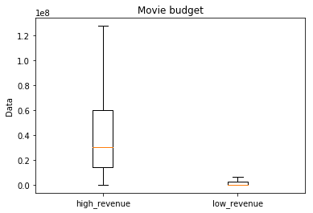

```python
plt.boxplot(x=(df_high['budget'],df_low['budget']),
            showfliers=False, meanline=True,
           labels=['high_revenue', 'low_revenue'])
plt.title('Movie budget')
plt.ylabel('Data');
```

上图显示，大部分票房较低电影的预算不到票房较高电影预算中位数的一半。

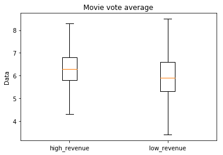

```python
plt.boxplot(x=(df_high['vote_average'],df_low['vote_average']),
            showfliers=False, meanline=True,
           labels=['high_revenue', 'low_revenue'])
plt.title('Movie vote average')
plt.ylabel('Data');
```

上图显示，票房较高和较低的电影评分数值相差不大，但是票房较高的电影，评分值更加集中，而票房低的电影评分值相对分散

## 结论

### 每年最受欢迎的电影的体裁是什么？

> 图表数据显示，大部分年份最受欢迎的电影的体裁按照排名先后为冒险、动作、科幻、惊险类电影。极少数年份最受欢迎的电影为音乐、浪漫体裁。数据包含了 1960 年到 2015 年所有每年最受欢迎的电影，大致能够体现出电影受欢迎程度，但不能保证电影只要包含前几名的体裁就一定会受欢迎。因为去除异常值和空值时，做了一些数据的测试，测试结果对数据影响不大，为了保证报告简洁最终删掉了测试代码。

### 票房高的电影有哪些特点？

> 图表数据显示，票房高的电影的受欢迎程度、预算、投票数量相对较高，与电影时长、投票平均分、发行年份则无很大关系。其中票房较低的大部分电影，受欢迎程度的值都在票房较高电影的中位数以下；大部分票房较低电影的预算不到票房较高电影预算中位数的一半；而票房较高和较低的电影评分数值虽然相差不大，但是票房较高的电影评分值更加集中，票房低的电影评分值相对分散。当然，这些数据对单个电影来讲可能并不成立，比如，有预算非常高的票房低的电影。